# Reproducible Research: Peer Assessment 1

## Global Settings

Below are the global settings used for the code

```r
library(knitr)
library(ggplot2)
opts_chunk$set(echo=TRUE,results="show")
```

## Loading and preprocessing the data

Please make sure you have the ‘activity.zip’ file in the current directory

```r
unzip('activity.zip')
AssignData <- read.csv('activity.csv')
head(AssignData)
```

```
##   steps       date interval
## 1    NA 2012-10-01        0
## 2    NA 2012-10-01        5
## 3    NA 2012-10-01       10
## 4    NA 2012-10-01       15
## 5    NA 2012-10-01       20
## 6    NA 2012-10-01       25
```

## What is mean total number of steps taken per day?

This section is to find the total number of steps taken per day and also to find the mean and median

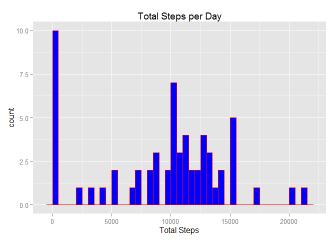

```r
TotalSteps <- tapply(AssignData$steps, AssignData$date, sum, na.rm=TRUE)
qplot(TotalSteps,
      geom="histogram",
      binwidth = 500,
      main = "Total Steps per Day",
      xlab = "Total Steps",
      fill=I("blue"),
      col=I("red"))
```

```r
totalmean <- mean(TotalSteps, na.rm=TRUE)
totalmedian <- median(TotalSteps, na.rm=TRUE)
```

The mean and median of the total number of steps taken per day are 9354.2295082 and 10395

## What is the average daily activity pattern?

In this part, a time series plot for 5 minute interval will be plotted and the max number of steps in a particular time will be estaimated

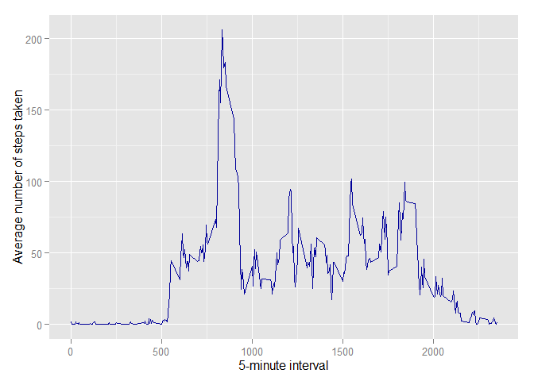

```r
AvgDaily <- aggregate(x=list(steps=AssignData$steps),
                      by=list(interval=AssignData$interval),
                      FUN=mean, na.rm=TRUE)
ggplot(data=AvgDaily, aes(x=interval, y=steps)) +
    geom_line(colour="#000099") +
    xlab("5-minute interval") +
    ylab("Average number of steps taken")
```

```r
MaxStepsIndex <- which.max(AvgDaily$steps)
MaxAvgDaily <- AvgDaily[MaxStepsIndex,1]
```

The maximum number of steps on average across all the days for the 5-minute interval was at 835

## Imputing missing values

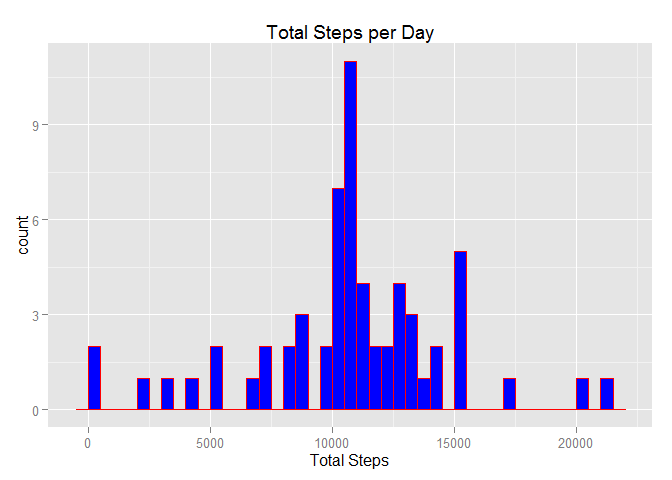

```r
NAIndex <- is.na(AssignData$steps)
Missing <- as.data.frame(table(NAIndex))
MissingCount<- Missing[2,2]
AvgDaily <- aggregate(x=list(steps=AssignData$steps),
                      by=list(interval=AssignData$interval),
                      FUN=mean, na.rm=TRUE)
n = nrow(AssignData)
NewData <- AssignData
for(i in 1:n)
{
  if (is.na(NewData$steps[i])==TRUE){
      indexfind <- which(AvgDaily$interval == NewData$interval[i])
      NewData$steps[i]=AvgDaily$steps[indexfind]
  }

}

NewTotalSteps <- tapply(NewData$steps, NewData$date, sum)
qplot(NewTotalSteps,
      geom="histogram",
      binwidth = 500,
      main = "Total Steps per Day",
      xlab = "Total Steps",
      fill=I("blue"),
      col=I("red"))
```

```r
Newtotalmean <- mean(NewTotalSteps)
Newtotalmedian <- median(NewTotalSteps)
```

## Are there differences in activity patterns between weekdays and weekends?

This section is to find the date falls in weekday or weekend to find the activity patterns between those two.

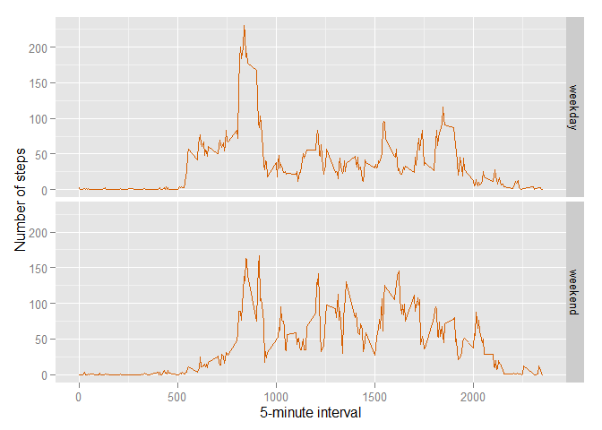

```r
NewData$date <- as.Date(NewData$date)
FindDay <- function(date) {
    day <- weekdays(date)
    if (day %in% c("Monday", "Tuesday", "Wednesday", "Thursday", "Friday"))
        return("weekday")
    else if (day %in% c("Saturday", "Sunday"))
        return("weekend")
    else
        stop("invalid date")
}
NewData$day <- sapply(NewData$date, FUN=FindDay)
averages <- aggregate(steps ~ interval + day, data=NewData, mean)
ggplot(averages, aes(interval, steps)) + geom_line(color="#D55E00") + facet_grid(day ~ .) +
    xlab("5-minute interval") + ylab("Number of steps")
```

The result shows that there is slightly different pattern for the weekday or Weekend.